# Transcriptomic trajectories

### Tier 2b

```r
# ============================================================
# TIER 2b (k = 5)
# ============================================================

tier2b_cluster_membership_k5 <- tibble(
  gene_id = names(tier2b_explore$k_5$clusters),
  cluster = tier2b_explore$k_5$clusters
)

# ------------------------------------------------------------
# Cluster membership
# ------------------------------------------------------------

tier2b_cluster_membership_k5 %>%
  arrange(cluster) %>%
  group_by(cluster) %>%
  summarise(
    N_Genes = n(),
    Genes = paste(gene_id, collapse = ", "),
    .groups = "drop"
  ) %>%
  knitr::kable(
    caption = "Tier 2b gene membership by cluster (k = 5)"
  )
```

Tier 2b gene membership by cluster (k = 5)

| cluster | N_Genes | Genes |
| --- | --- | --- |
| 1 | 30 | TRINITY_GG_1293_c9_g3, TRINITY_GG_1604_c19_g4, TRINITY_GG_394_c173_g1, TRINITY_GG_446_c1914_g1, TRINITY_GG_394_c28_g1, TRINITY_GG_1406_c103_g1, TRINITY_GG_809_c60_g3, TRINITY_GG_867_c54_g1, TRINITY_GG… |
| 2 | 7 | TRINITY_GG_225_c768_g1, TRINITY_GG_1348_c8_g7, TRINITY_GG_595_c6_g2, TRINITY_GG_11_c0_g1, TRINITY_GG_489_c47_g1, TRINITY_GG_1600_c23_g3, TRINITY_GG_1008_c49_g2 |
| 3 | 1 | TRINITY_GG_759_c39_g1 |
| 4 | 6 | TRINITY_GG_951_c83_g1, TRINITY_GG_68_c39_g1, TRINITY_GG_282_c110_g1, TRINITY_GG_1263_c113_g2, TRINITY_GG_131_c6_g2, TRINITY_GG_234_c142_g3 |
| 5 | 1 | TRINITY_GG_722_c27_g2 |

```r
# ------------------------------------------------------------
# Cluster profiles
# ------------------------------------------------------------

tier2b_explore$k_5$profile_table %>%
  knitr::kable(
    digits = 2,
    caption = "Cluster profiles for k = 5"
  )
```

Cluster profiles for k = 5

| Cluster | W12 | W15 | W18 | H12 | H15 | H18 | S12 | S15 | S18 |
| --- | --- | --- | --- | --- | --- | --- | --- | --- | --- |
| 1 | 0.87 | -0.40 | -1.50 | 0.86 | -0.29 | -1.01 | 1.34 | -0.53 | 0.65 |
| 2 | 0.43 | -0.12 | 1.55 | 0.26 | 0.04 | 0.50 | -0.14 | -1.16 | -1.34 |
| 3 | -1.02 | -0.07 | -0.77 | 0.12 | -0.05 | -0.43 | 2.47 | -0.06 | -0.20 |
| 4 | 0.30 | 0.10 | -2.08 | 0.32 | -0.21 | -0.79 | 0.75 | 0.66 | 0.95 |
| 5 | -0.40 | -0.24 | -0.48 | -0.32 | -0.45 | -0.17 | 0.02 | 2.62 | -0.58 |

```
##
##
## ### Cluster 1
```

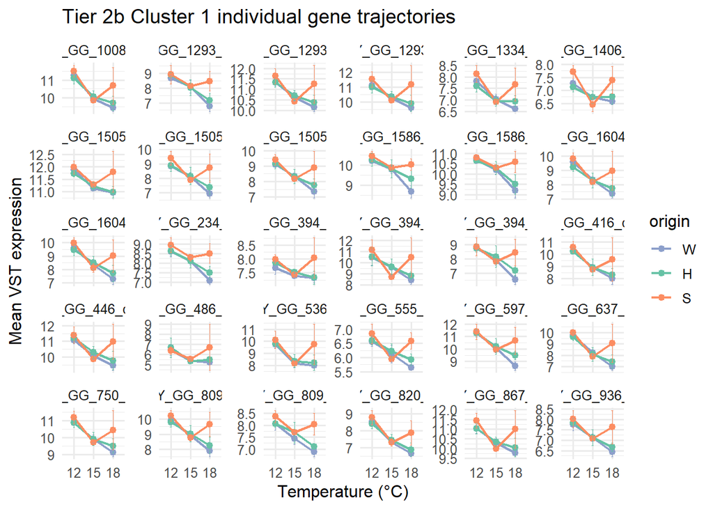

```
##
##
## ### Cluster 2
```

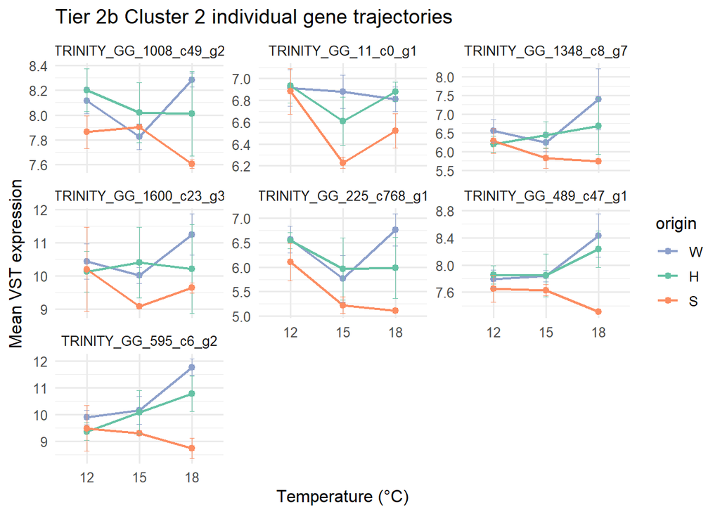

```
##
##
## ### Cluster 3
```

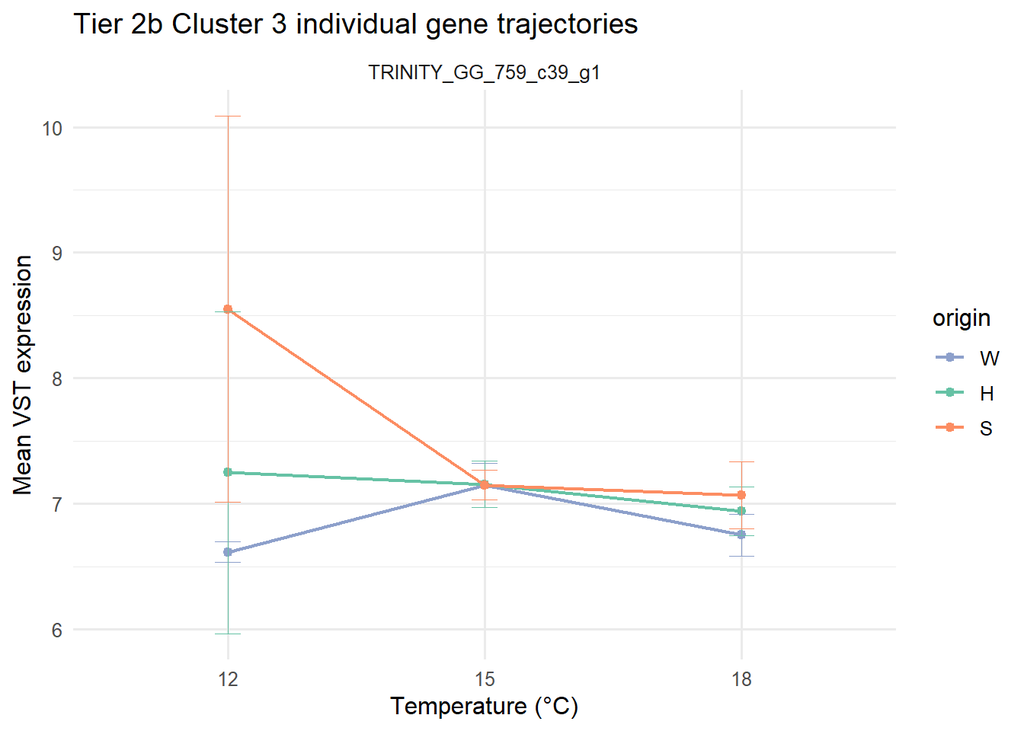

```
##
##
## ### Cluster 4
```

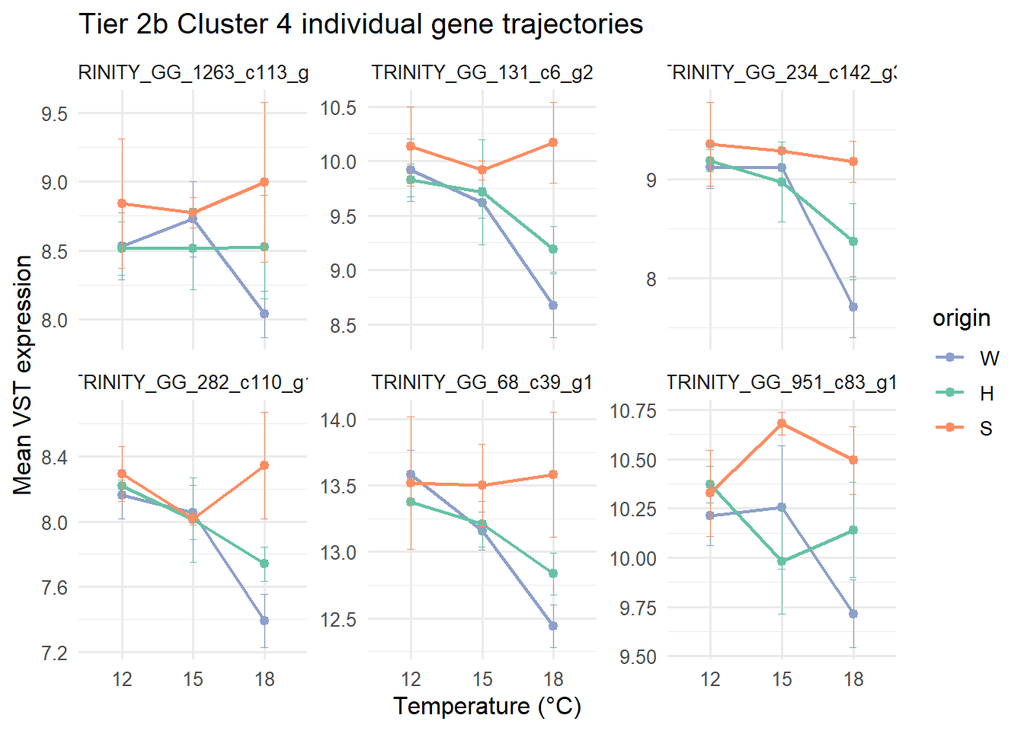

```
##
##
## ### Cluster 5
```

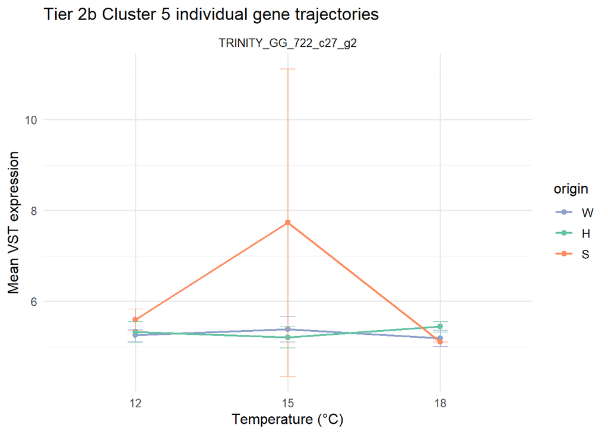

```r
# ------------------------------------------------------------
# Individual gene trajectories by cluster
# ------------------------------------------------------------

tier2b_gene_plots <- list()

for(cl in sort(unique(tier2b_cluster_membership_k5$cluster))) {

  cluster_genes <- tier2b_cluster_membership_k5 %>%
    filter(cluster == cl) %>%
    pull(gene_id)

  cat("\n\n")
  cat("### Cluster", cl, "\n\n")

  cluster_plot <- plot_gene_panel(
    gene_ids = cluster_genes,
    expr_matrix = expr_matrix,
    metadata = metadata,
    title_text = paste(
      "Tier 2b Cluster",
      cl,
      "individual gene trajectories"
    )
  )

  tier2b_gene_plots[[paste0("cluster_", cl)]] <- cluster_plot

  print(cluster_plot)

}
```

Individual gene trajectories were highly consistent within clusters and closely followed the expression patterns identified.

### TIER 1 ∩ TIER 3 missexpressed

```r
# ============================================================
# TIER 1 ∩ TIER 3 (k = 4)
# ============================================================

tier1_tier3_cluster_membership_k4 <- tibble(
  gene_id = names(tier1_tier3_explore$k_4$clusters),
  cluster = tier1_tier3_explore$k_4$clusters
)

# ------------------------------------------------------------
# Cluster membership
# ------------------------------------------------------------

tier1_tier3_cluster_membership_k4 %>%
  arrange(cluster) %>%
  group_by(cluster) %>%
  summarise(
    N_Genes = n(),
    Genes = paste(gene_id, collapse = ", "),
    .groups = "drop"
  ) %>%
  knitr::kable(
    caption = "Tier 1 ∩ Tier 3 gene membership by cluster (k = 4)"
  )
```

Tier 1 ∩ Tier 3 gene membership by cluster (k = 4)

| cluster | N_Genes | Genes |
| --- | --- | --- |
| 1 | 8 | TRINITY_GG_597_c30_g1, TRINITY_GG_416_c23_g1, TRINITY_GG_957_c157_g1, TRINITY_GG_415_c12_g1, TRINITY_GG_1118_c12_g1, TRINITY_GG_1115_c7_g6, TRINITY_GG_370_c127_g1, TRINITY_GG_448_c236_g1 |
| 2 | 3 | TRINITY_GG_1219_c1_g1, TRINITY_GG_283_c70_g1, TRINITY_GG_131_c77_g5 |
| 3 | 5 | TRINITY_GG_866_c19_g1, TRINITY_GG_225_c3_g1, TRINITY_GG_602_c87_g1, TRINITY_GG_1503_c14_g3, TRINITY_GG_1462_c182_g1 |
| 4 | 7 | TRINITY_GG_722_c7_g3, TRINITY_GG_165_c3_g1, TRINITY_GG_1107_c123_g1, TRINITY_GG_867_c1_g3, TRINITY_GG_234_c4_g1, TRINITY_GG_595_c167_g1, TRINITY_GG_446_c69_g1 |

```r
# ------------------------------------------------------------
# Cluster profiles
# ------------------------------------------------------------

tier1_tier3_explore$k_4$profile_table %>%
  knitr::kable(
    digits = 2,
    caption = "Cluster profiles for k = 4"
  )
```

Cluster profiles for k = 4

| Cluster | W12 | W15 | W18 | H12 | H15 | H18 | S12 | S15 | S18 |
| --- | --- | --- | --- | --- | --- | --- | --- | --- | --- |
| 1 | 1.04 | -0.07 | -1.66 | 0.95 | -0.23 | -1.15 | 1.17 | 0.07 | -0.13 |
| 2 | -1.21 | 1.13 | -0.02 | -0.88 | 0.98 | 0.22 | -0.88 | 1.21 | -0.54 |
| 3 | 1.26 | -0.96 | -0.29 | 0.80 | -0.81 | -0.19 | 1.29 | -1.30 | 0.19 |
| 4 | -1.12 | -0.17 | 1.54 | -1.03 | 0.05 | 1.13 | -0.84 | 0.67 | -0.22 |

```
##
##
## ### Cluster 1
```

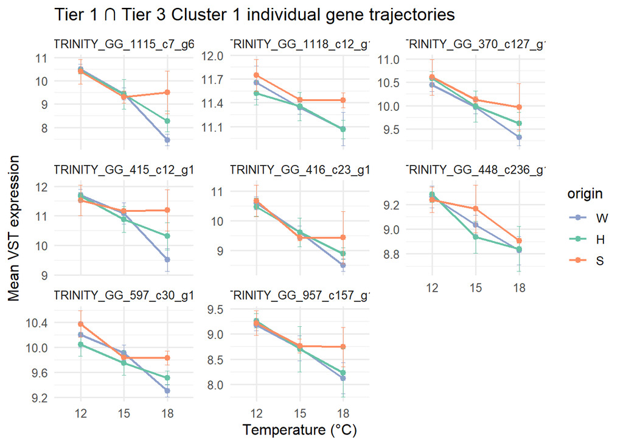

```
##
##
## ### Cluster 2
```

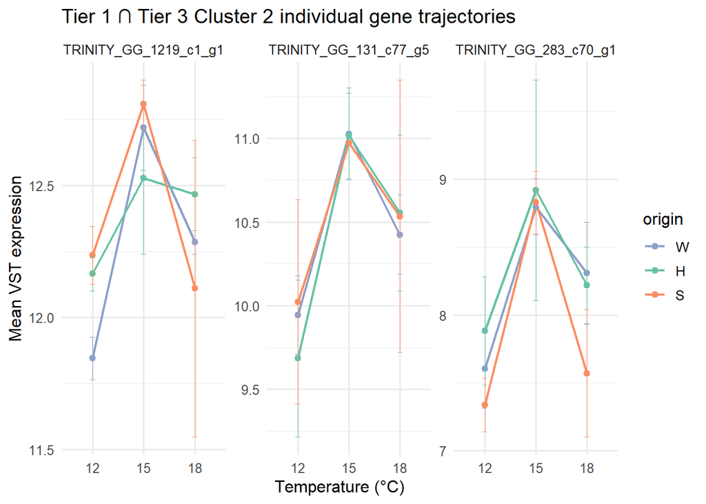

```
##
##
## ### Cluster 3
```

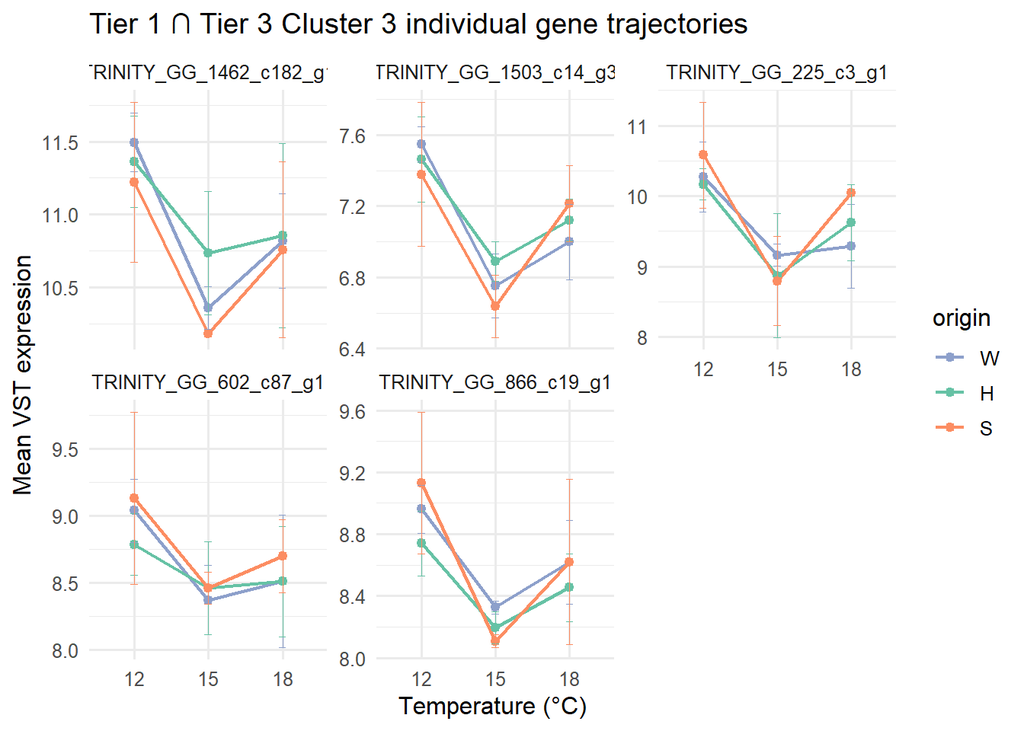

```
##
##
## ### Cluster 4
```

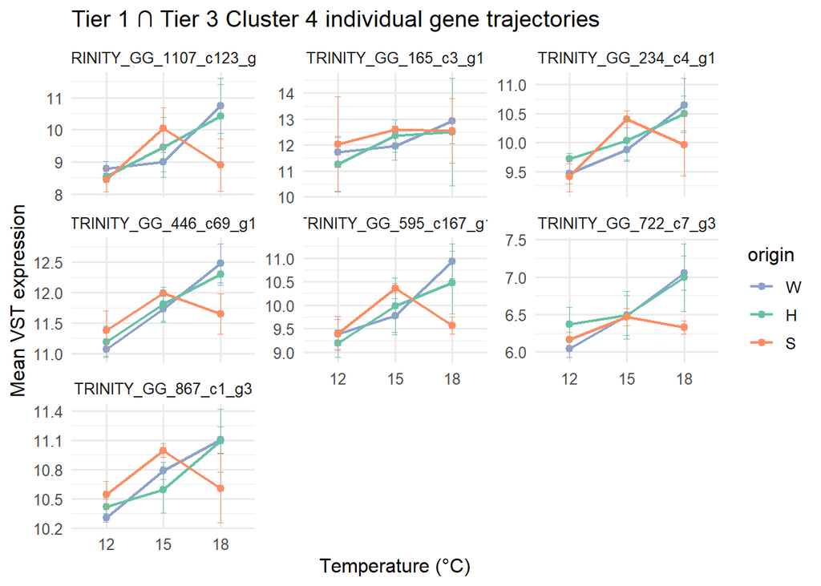

```r
# ------------------------------------------------------------
# Individual gene trajectories by cluster
# ------------------------------------------------------------

tier1_tier3_gene_plots <- list()

for(cl in sort(unique(tier1_tier3_cluster_membership_k4$cluster))) {

  cluster_genes <- tier1_tier3_cluster_membership_k4 %>%
    filter(cluster == cl) %>%
    pull(gene_id)

  cat("\n\n")
  cat("### Cluster", cl, "\n\n")

  cluster_plot <- plot_gene_panel(
    gene_ids = cluster_genes,
    expr_matrix = expr_matrix,
    metadata = metadata,
    title_text = paste(
      "Tier 1 ∩ Tier 3 Cluster",
      cl,
      "individual gene trajectories"
    )
  )

  tier1_tier3_gene_plots[[paste0("cluster_", cl)]] <- cluster_plot

  print(cluster_plot)

}
```

Individual gene trajectories closely matched the expression patterns identified by hierarchical clustering, indicating that the four-cluster solution reflected coherent gene-level responses.

### TIER 2b ∩ TIER 3 missexpressed

```r
# ============================================================
# TIER 2b ∩ TIER 3 MISEXPRESSED
# ============================================================

trajectory_values <- lapply(
  tier2b_tier3_mis_genes,
  function(gene){

    df <- data.frame(
      sample = colnames(expr_matrix),
      expression = as.numeric(expr_matrix[gene, ])
    ) %>%
      left_join(metadata, by = "sample") %>%
      group_by(origin, temperature) %>%
      summarise(
        Mean = mean(expression),
        .groups = "drop"
      )

    tibble(
      Gene_ID = gene,
      W12 = df$Mean[df$origin == "W" & df$temperature == 12],
      W15 = df$Mean[df$origin == "W" & df$temperature == 15],
      W18 = df$Mean[df$origin == "W" & df$temperature == 18],
      H12 = df$Mean[df$origin == "H" & df$temperature == 12],
      H15 = df$Mean[df$origin == "H" & df$temperature == 15],
      H18 = df$Mean[df$origin == "H" & df$temperature == 18],
      S12 = df$Mean[df$origin == "S" & df$temperature == 12],
      S15 = df$Mean[df$origin == "S" & df$temperature == 15],
      S18 = df$Mean[df$origin == "S" & df$temperature == 18]
    )

  }
) %>%
  bind_rows()

knitr::kable(
  trajectory_values,
  digits = 2,
  caption = "Trajectory values for the Tier 2b ∩ Tier 3 misexpressed gene"
)
```

Trajectory values for the Tier 2b ∩ Tier 3 misexpressed gene

| Gene_ID | W12 | W15 | W18 | H12 | H15 | H18 | S12 | S15 | S18 |
| --- | --- | --- | --- | --- | --- | --- | --- | --- | --- |
| TRINITY_GG_597_c47_g1 | 11.24 | 10.06 | 8.61 | 11.25 | 10.2 | 9.48 | 11.37 | 9.95 | 10.65 |

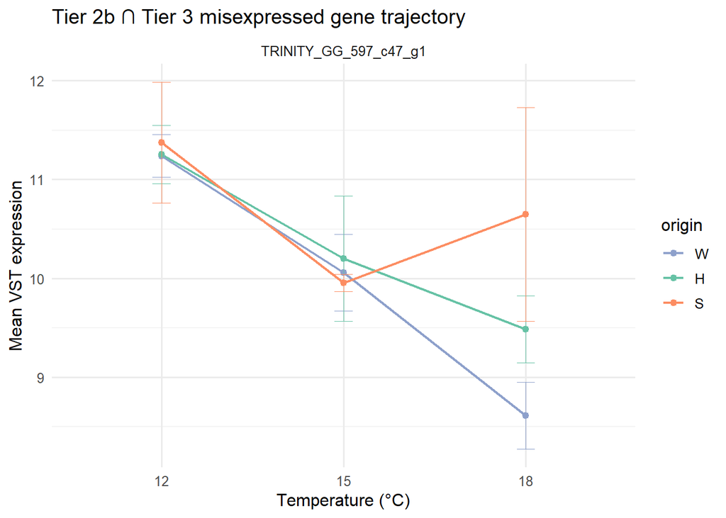

```r
tier2b_tier3_gene_plot <- plot_gene_panel(
  gene_ids = tier2b_tier3_mis_genes,
  expr_matrix = expr_matrix,
  metadata = metadata,
  title_text = "Tier 2b ∩ Tier 3 misexpressed gene trajectory"
)

print(tier2b_tier3_gene_plot)
```

The overlap between Tier 2b and Tier 3 misexpressed genes consisted of a single CD81-like gene that exhibited within-range misexpression only at 18°C, indicating that hybrid expression remained intermediate between the parental expression levels despite being significantly differentiated from both parental populations. While the overall number of misexpressed genes showed little variation across temperatures and substantial trajectory heterogeneity overall, this finding raises the possibility that hybridization may disrupt expression of particular local thermal adaptation candidates under warmer conditions.

## South-West expression divergence across temperatures

Differential expression analyses identified multiple gene sets that differed in their responses to temperature and population origin. However, differential expression alone does not quantify the magnitude of expression divergence between parental populations. To evaluate how strongly Southern and Western populations differed transcriptionally within each gene set, we quantified South-West expression divergence across temperatures. For each gene, mean expression was calculated separately for each parental origin (Southern and Western) at each temperature treatment. Gene-level parental divergence was then defined as the absolute difference in mean expression between origins (|S − W|). This metric captures the magnitude of population differentiation irrespective of the direction of expression change. To compare patterns among gene sets, gene-level divergence values were summarized within each temperature and gene set. Mean parental divergence was estimated from the resulting gene-level distributions, and uncertainty around these estimates was quantified using non-parametric bootstrap resampling of genes within each gene set (100,000 bootstrap replicates). The 2.5th and 97.5th percentiles of the bootstrap distributions were used to construct 95% confidence intervals around mean divergence estimates. Divergence trajectories and their associated bootstrap confidence intervals were then visualized across temperatures to compare patterns of parental expression divergence among gene sets.

#### South-West expression divergence across temperatures

```r
# ============================================================
# CALCULATE GENE-LEVEL MEAN EXPRESSION
# ============================================================

genes_for_divergence <- unique(c(
  tier1_genes,
  tier2_genes,
  interaction_genes,
  tier2b_genes,
  tier3_mis_genes,
  tier1_tier3_mis_genes
))

genes_for_divergence <- intersect(
  genes_for_divergence,
  rownames(expr_matrix)
)

gene_means <- lapply(
  genes_for_divergence,
  function(gene) {

    data.frame(
      gene = gene,
      sample = colnames(expr_matrix),
      expression = as.numeric(expr_matrix[gene, ])
    ) %>%
      left_join(
        metadata,
        by = "sample"
      ) %>%
      group_by(
        gene,
        origin,
        temperature
      ) %>%
      summarise(
        mean_expression = mean(expression),
        .groups = "drop"
      )

  }
) %>%
  bind_rows()

# ============================================================
# BUILD GENE-LEVEL DIVERGENCE DATA
# ============================================================

# Calculate South-West divergence for each gene
divergence_by_gene <- gene_means %>%
  filter(origin %in% c("S", "W")) %>%
  pivot_wider(
    names_from = origin,
    values_from = mean_expression
  ) %>%
  mutate(
    parental_divergence = abs(S - W)
  )

# Combine focal gene sets into a single table
plot_data <- bind_rows(

  divergence_by_gene %>%
    filter(gene %in% tier1_genes) %>%
    mutate(Gene_Set = "Tier 1"),

  divergence_by_gene %>%
    filter(gene %in% tier2_genes) %>%
    mutate(Gene_Set = "Tier 2"),

  divergence_by_gene %>%
    filter(gene %in% interaction_genes) %>%
    mutate(Gene_Set = "Interaction genes"),

  divergence_by_gene %>%
    filter(gene %in% tier2b_genes) %>%
    mutate(Gene_Set = "Tier 2b"),

  divergence_by_gene %>%
    filter(gene %in% tier3_mis_genes) %>%
    mutate(Gene_Set = "Tier 3 Misexpressed"),

  divergence_by_gene %>%
    filter(gene %in% tier1_tier3_mis_genes) %>%
    mutate(Gene_Set = "Tier1 ∩ Tier3 Misexpressed")
)

# ============================================================
# BOOTSTRAP CONFIDENCE INTERVALS
# ============================================================

set.seed(123)

n_boot <- 100000

bootstrap_results <- plot_data %>%
  group_by(
    Gene_Set,
    temperature
  ) %>%
  group_modify(~{

    x <- .x$parental_divergence

    boot_means <- replicate(
      n_boot,
      mean(
        sample(
          x,
          size = length(x),
          replace = TRUE
        )
      )
    )

    tibble(
      Mean_Divergence = mean(x),
      CI_Lower = quantile(boot_means, 0.025),
      CI_Upper = quantile(boot_means, 0.975),
      N_Genes = length(x),
      SD_Divergence = sd(x)
    )

  }) %>%
  ungroup()

knitr::kable(
  bootstrap_results,
  digits = 3,
  caption = "Bootstrap confidence intervals for South-West divergence"
)
```

Bootstrap confidence intervals for South-West divergence

| Gene_Set | temperature | Mean_Divergence | CI_Lower | CI_Upper | N_Genes | SD_Divergence |
| --- | --- | --- | --- | --- | --- | --- |
| Interaction genes | 12 | 0.201 | 0.187 | 0.215 | 977 | 0.219 |
| Interaction genes | 15 | 0.283 | 0.267 | 0.299 | 977 | 0.251 |
| Interaction genes | 18 | 0.959 | 0.927 | 0.991 | 977 | 0.516 |
| Tier 1 | 12 | 0.159 | 0.149 | 0.170 | 593 | 0.131 |
| Tier 1 | 15 | 0.240 | 0.221 | 0.260 | 593 | 0.244 |
| Tier 1 | 18 | 0.693 | 0.648 | 0.739 | 593 | 0.566 |
| Tier 2 | 12 | 0.378 | 0.370 | 0.387 | 1498 | 0.176 |
| Tier 2 | 15 | 0.285 | 0.273 | 0.297 | 1498 | 0.243 |
| Tier 2 | 18 | 0.661 | 0.642 | 0.681 | 1498 | 0.386 |
| Tier 2b | 12 | 0.311 | 0.246 | 0.403 | 45 | 0.280 |
| Tier 2b | 15 | 0.283 | 0.189 | 0.409 | 45 | 0.385 |
| Tier 2b | 18 | 1.340 | 1.188 | 1.495 | 45 | 0.529 |
| Tier 3 Misexpressed | 12 | 0.216 | 0.199 | 0.233 | 727 | 0.232 |
| Tier 3 Misexpressed | 15 | 0.236 | 0.218 | 0.256 | 727 | 0.263 |
| Tier 3 Misexpressed | 18 | 0.430 | 0.400 | 0.460 | 727 | 0.409 |
| Tier1 ∩ Tier3 Misexpressed | 12 | 0.172 | 0.129 | 0.217 | 23 | 0.110 |
| Tier1 ∩ Tier3 Misexpressed | 15 | 0.234 | 0.144 | 0.343 | 23 | 0.249 |
| Tier1 ∩ Tier3 Misexpressed | 18 | 0.672 | 0.454 | 0.914 | 23 | 0.575 |

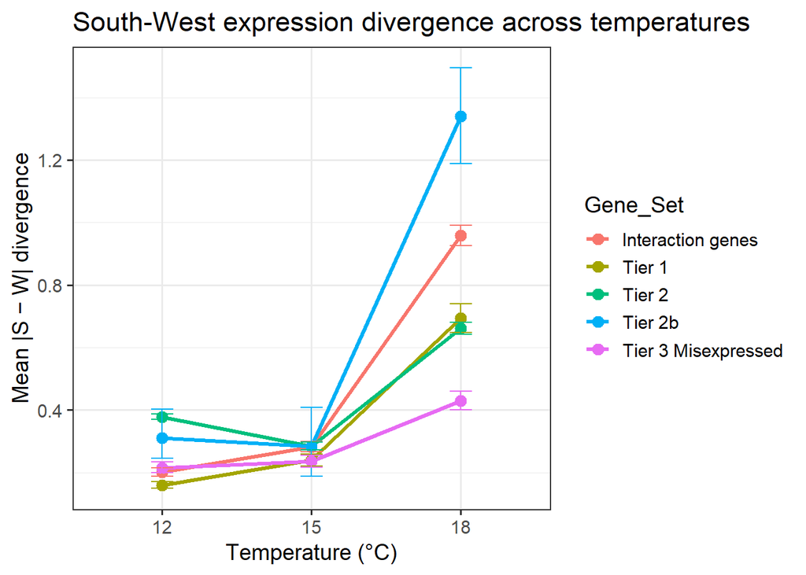

```r
# ============================================================
# PLOT MAJOR GENE SETS ONLY
# ============================================================

plot_bootstrap <- bootstrap_results %>%
  filter(
    Gene_Set != "Tier1 ∩ Tier3 Misexpressed"
  )

ggplot(
  plot_bootstrap,
  aes(
    x = factor(temperature),
    y = Mean_Divergence,
    colour = Gene_Set,
    group = Gene_Set
  )
) +
  geom_line(linewidth = 1.2) +
  geom_point(size = 3) +
  geom_errorbar(
    aes(
      ymin = CI_Lower,
      ymax = CI_Upper
    ),
    width = 0.15,
    linewidth = 0.5
  ) +
  labs(
    x = "Temperature (°C)",
    y = "Mean |S − W| divergence",
    title = "South-West expression divergence across temperatures"
  ) +
  theme_bw(base_size = 14)
```

#### Divergence patterns across temperatures

- **12°C:** Tier 2 ≈ Tier 2b > Tier 3 Misexpressed ≈ Interaction genes ≈ Tier1 ∩ Tier3 Misexpressed > Tier 1
- **15°C:** Tier 2 ≈ Interaction genes > Tier 1 ≈ Tier 3 Misexpressed, whereas Tier 2b and Tier1 ∩ Tier3 Misexpressed overlap all major gene sets due to their wider confidence intervals.
- **18°C:** Tier 2b > Interaction genes > Tier 1 ≈ Tier1 ∩ Tier3 Misexpressed ≈ Tier 2 > Tier 3 Misexpressed

#### Observations

- At 12°C, Tier 2 genes showed the greatest parental divergence (0.378, 95% CI = 0.370–0.387), consistent with their definition as population-divergence genes, followed by Tier 2b genes (0.311, 95% CI = 0.245–0.404). The overlap in bootstrap confidence intervals is consistent with Tier 2b being a small subset of the broader Tier 2 gene set and suggests that local adaptation candidates retain the elevated parental expression divergence characteristic of Tier 2 genes.
- At 15°C, divergence values converged across gene sets. This convergence was driven by a reduction in parental divergence among Tier 2 and Tier 2b genes relative to 12°C, together with increased divergence among Tier 1, interaction genes, Tier 3 Misexpressed genes, and the Tier1 ∩ Tier3 Misexpressed overlap set. As a result, mean divergence values fell within a relatively narrow range (0.236-0.285).
- Despite this overall convergence at 15°C, Tier 2 genes (0.285, 95% CI = 0.273-0.297) and interaction genes (0.283, 95% CI = 0.267-0.299) exhibited higher divergence than Tier 1 genes (0.240, 95% CI = 0.221-0.260) and Tier 3 Misexpressed genes (0.236, 95% CI = 0.218-0.256). In contrast, the Tier 2b and Tier1 ∩ Tier3 Misexpressed overlap sets exhibited broad confidence intervals that overlapped all gene sets, reflecting the relatively small number of genes in these categories.
- At 18°C, divergence increased in every gene set, indicating that elevated temperature generally amplified transcriptional differences between Southern and Western populations. The magnitude of this increase differed markedly among gene sets. Tier 2b genes exhibited the highest divergence at 18°C (1.340, 95% CI = 1.188–1.494), followed by interaction genes (0.959, 95% CI = 0.927–0.991). Tier 1 (0.693, 95% CI = 0.648–0.739) and Tier 2 (0.661, 95% CI = 0.642–0.681) exhibited similar levels of divergence, whereas Tier 3 Misexpressed genes showed substantially lower divergence (0.430, 95% CI = 0.401–0.460).
- Tier 2b genes showed the largest temperature-dependent increase in divergence, rising from 0.311 at 12°C to 1.340 at 18°C. Tier 2b genes displayed substantial parental expression divergence at 12°C, consistent with their derivation from the Tier 2 population-divergence gene set. Their divergence might therefore be expected to resemble either the broader Tier 2 or interaction gene sets. Instead, Tier 2b genes exceeded both groups at 18°C, becoming the most highly differentiated gene set. This pattern supports the biological relevance of the Tier 2b classification and suggests that the combination of population divergence and temperature-dependent regulatory divergence identifies a particularly differentiated subset of genes.
- Interaction genes also showed a strong divergence increase at 18°C, suggesting that many of the significant origin-by-temperature interactions detected by DESeq2 are driven by transcriptional differences that become most apparent under the warmest treatment.
- Tier 1 genes exhibited the lowest parental divergence at 12°C (0.159, 95% CI = 0.149–0.170), consistent with their definition as conserved temperature-responsive genes. However, divergence increased substantially with temperature, reaching 0.693 (95% CI = 0.648–0.739) at 18°C and exceeding that observed in the broader Tier 3 Misexpressed gene set (0.430, 95% CI = 0.401–0.460). This pattern suggests that conserved transcriptional responses to temperature can become increasingly differentiated between parental populations under warmer conditions.
- Interestingly, the Tier1 ∩ Tier3 Misexpressed overlap set occupied an intermediate position between Tier 1 and Tier 3 Misexpressed genes at 12°C, consistent with its origin as an intersection of the two categories. At 18°C, its mean divergence (0.672) was considerably closer to that of Tier 1 genes (0.693) than the broader Tier 3 Misexpressed gene set (0.430), although confidence intervals remained wide owing to the small size of the overlap set (not displayed in the figure owing to its wide confidence intervals).

#### Biological interpretations

Together, these results support the biological relevance of the Tier 2b extraction strategy. Tier 2b genes displayed substantial parental expression divergence at 12°C, consistent with their derivation from the Tier 2 population-divergence gene set, but also exhibited the strongest divergence increase at 18°C, where they became the most highly differentiated gene set. Tier 2b genes exceeded interaction genes in parental divergence at 18°C, indicating that the combination of population divergence and origin-specific thermal responses identifies a particularly differentiated subset of genes.

Despite exhibiting the highest levels of parental divergence, only a single Tier 2b gene (CD81-like) was misexpressed in hybrids. In contrast, the broader set of Tier 3 misexpressed genes remained comparatively weakly diverged. These findings indicate that hybrid misexpression is not strongly associated with the magnitude of population divergence and suggest that most adaptive regulatory differences remain compatible in hybrids. Nevertheless, the temperature-dependent misexpression of the highly divergent Tier 2b gene CD81-like raises the possibility that elevated temperature can expose regulatory incompatibilities at specific adaptive loci.

#### Caveat

Because only two Southern individuals were available at 15°C and 18°C, estimates of parental divergence at these temperatures should be interpreted with some caution. However, the reduced divergence differences observed among gene sets at 15°C, together with the disproportionately large increase observed specifically for interaction genes and Tier 2b candidates at 18°C, suggests that the observed patterns are unlikely to be fully explained by sampling variation.

## Summary

PCA trajectory analyses revealed a distinct Southern transcriptional response to temperature, characterized by movement away from the 12°C transcriptomic state at 15°C followed by partial return toward the 12°C state at 18°C. This recovery pattern was observed across the whole transcriptome and all focal gene sets, indicating that it represents a pervasive feature of the Southern response to temperature. Hybrid trajectories generally resembled those of Western fish but exhibited reduced transcriptomic displacement across the temperature gradient. The magnitude of the Southern trajectory reversal varied among gene sets and closely reflected their biological definitions. Reversal was weakest among Tier 1 conserved temperature-responsive genes, suggesting that the Southern recovery pattern is less pronounced among genes contributing to the core thermal-response program shared across populations. In contrast, interaction genes and Tier 2b local adaptation candidates exhibited the strongest reversals, consistent with the Southern recovery response representing a distinct Southern strategy for responding to temperature. Tier 2 population-divergence genes exhibited reversal similar to that observed across the whole transcriptome, suggesting that the Southern recovery pattern alone is unlikely to account for the differential expression observed between parental populations. Both Tier 3 misexpressed genes and the Tier 1 ∩ Tier 3 overlap exhibited relatively strong reversal, supporting an association between the Southern recovery response and hybrid misexpression.

Hierarchical clustering revealed that different gene sets were characterized by distinct transcriptional response architectures. Tier 1 genes recovered multiple temperature-response patterns, but a consistent feature across clusters was that Southern fish exhibited stronger non-linear responses than Western and Hybrid fish, whereas hybrid trajectories generally resembled those of Western fish with reduced response magnitudes. In contrast, Tier 2 genes were dominated by two broad expression programs, demonstrating that transcriptional differences among populations can arise through both differences in expression level despite similar response trajectories and differences in the trajectory of the transcriptional response itself. Interaction genes and Tier 2b local adaptation candidates exhibited the strongest evidence for origin-specific thermal responses. In both gene sets, Western and Hybrid fish frequently followed similar trajectories, whereas Southern fish showed distinct and often more pronounced non-linear responses. Tier 2b candidates were particularly notable because most genes exhibited their strongest population-specific expression differences under the warmest treatment, consistent with the strong increase in parental divergence observed at 18°C. Nevertheless, the singleton trajectories represented by SAMD9L and TM6SF1 demonstrated that unique population-specific thermal responses can also occur at lower temperatures. In contrast, Tier 3 misexpressed genes exhibited comparatively weak clustering structure despite comprising hundreds of genes. Misexpressed genes were distributed across multiple response architectures, and the Tier 1 ∩ Tier 3 overlap recovered the same major trajectory patterns observed in the broader Tier 1 gene set. Together with the limited overlap of misexpressed genes across temperatures observed in the Tier 3 analysis, these results indicate that hybrid misexpression is distributed across diverse genes and transcriptional response patterns rather than concentrated within a distinct regulatory program.

Expression divergence analyses revealed substantial differences among gene sets in how transcriptional differentiation between Southern and Western populations changed across the thermal gradient. Although divergence values converged across gene sets at 15°C, divergence increased markedly at 18°C, indicating that elevated temperature generally amplified transcriptional differences between populations. Tier 2b genes already exhibited substantial expression divergence between Southern and Western populations at 12°C and showed the strongest divergence increase at 18°C, where they became the most highly differentiated gene set. Tier 2b genes exceeded both the broader Tier 2 and interaction gene sets in parental divergence at the warmest treatment, suggesting that the combination of population divergence and origin-specific thermal responses identifies a particularly differentiated subset of genes. Despite exhibiting the highest levels of parental divergence, only a single Tier 2b gene (CD81-like) was misexpressed in hybrids. In contrast, the broader set of Tier 3 misexpressed genes remained comparatively weakly diverged. Together, these findings suggest that hybrid misexpression is not strongly associated with the magnitude of parental expression divergence and that most population-specific regulatory differences remain compatible in hybrids. Nevertheless, the temperature-dependent misexpression of the highly divergent CD81-like gene raises the possibility that elevated temperature can expose regulatory incompatibilities at specific loci.